# Evaluating Family Engagement and Disparities in Health Information Access through Patient Portal Use within a NICU

## Exploration and Manipulation of Access Table

```r
#When I initially queried the access information table for my included patients, it contained 37 million rows of information. After some data cleaning and in the interest of simpliying my data utilization in RStudio, I filtered specifically for pta.ua_time BETWEEN fne.episode_start_date AND fne.episode_end_date to make sure that the results only occured while a patient was admitted during my time window.

# Count total unique rows, gives total number of messages provided in filtered data set
total_unique_access <- nrow(access_data)

# Count total unique patients, gives total number of patients who had their MyChart accessed during NICU admission
total_unique_access_pat <- length(unique(access_data$MRN))

# Display results
cat("Total unique accesses:", total_unique_access, "\nNumber of unique patients:", total_unique_access_pat, "\n")
```

```
Total unique accesses: 3138958
Number of unique patients: 4517
```

Filtering table to only include patient access to MyChart (remove ShareEveryhere and External_Client)

```r
# Table to show counts of different individuals accessing MyChart
table(access_data$UA_PERSON_TYPE_C)
```

```
      1       2       3       4
3138393     448     114       3
```

```r
#Filtering for only patient and user (proxy)
access_data <- access_data |>
  dplyr::filter(access_data$UA_PERSON_TYPE_C %in% c(1, 2))
```

Utilization of a lookup table to understand the numeric values of MYC_UA_TYPE_C. This column uses a numeric value which I then associated with the lookup table I created from the Epic User Web to understand the action being completed.

```r
#Visualizing the top 30 actions of a total 466 variables
head(epic_lookup_table, n = 30)
```

```
   Code               Description
1     0                     Other
2     1                     Login
3     2               Medications
4     3                 Allergies
5     4       Test Result Details
6     5             Immunizations
7     6        Health Maintenance
8     7            Health Summary
9     8         Medical Histories
10    9          Encounter Review
11   10              Demographics
12   11              Problem List
13   12                    Visits
14   13           Account Inquiry
```

[output cut: 16 more lines]

```r
# Join `access_data` with `epic_lookup_table`
access_data <- access_data |>
  left_join(epic_lookup_table, by = c("MYC_UA_TYPE_C" = "Code")) |>
  rename(Activity_Description = Description)
```

In exploring the data and process mapping the steps involved in accessing MyChart, we identified that meaningful use of MyChart extends beyond initial setup and login activity. To ensure we capture meaningful engagement, we defined ‘meaningful access’ as instances where a patient had three or more actions in MyChart.

```r
# Filtering patients with less than 3
patients_less_than_3 <- access_data |>
  group_by(MRN) |>
  summarise(access_count = n()) |>
  filter(access_count < 3)

# Bring along activity descriptions by filtering the original dataset
patients_less_than_3_activities <- access_data |>
  semi_join(patients_less_than_3, by = "MRN") |>  # Filter to keep only patients with less than 5 accesses
  left_join(epic_lookup_table, by = c("MYC_UA_TYPE_C" = "Code"))  # Join to get activity descriptions

# Summarize
summary_activities <- patients_less_than_3_activities |>
  group_by(Activity_Description) |>
  summarise(
    Num_Patients = n_distinct(MRN),
    Total_Accesses = n()
  ) |>
  arrange(desc(Total_Accesses))

# Display results
summary_activities
```

```
# A tibble: 11 × 3
   Activity_Description                  Num_Patients Total_Accesses
   <chr>                                        <int>          <int>
 1 Demographics                                   197            295
 2 <NA>                                           131            134
 3 Welcome Shell Account Creation                  60             60
 4 Account Details                                 11             12
 5 Visits                                           7             12
 6 Proxy Context Exit                               4              5
 7 Standard Guarantor Payment                       5              5
 8 Telehealth Direct Join Link generated            2              3
 9 Guest Payment                                    2              2
10 HB Account Details                               1              1
11 Proxy Context Enter                              1              1
```

Addition of a column into the initial admissions table to account for whether or not a patient accessed their MyChart account DURING their hospital stay

```r
# Identify patients who accessed their MyChart DURING their initial NICU admission
accessed_mychart <- access_data |>
  inner_join(initial_admissions, by = "MRN") |>
  filter(UA_TIME >= EPISODE_START_DATE & UA_TIME <= EPISODE_END_DATE) |>
  select(MRN) |>
  distinct()

# Remove MRNs with less than 3 accesses from accessed_mychart
accessed_mychart_filtered <- accessed_mychart |>
  filter(!MRN %in% patients_less_than_3$MRN)

# Add MyChart_Access column to initial_admissions
initial_admissions <- initial_admissions |>
  mutate(MyChart_Access = ifelse(MRN %in% accessed_mychart_filtered$MRN, 1, 0))

# Conversion to factor
initial_admissions$MyChart_Access <- factor(initial_admissions$MyChart_Access,
                                            levels = c(0, 1),
                                            labels = c("No Access", "Accessed"))

# Total number of patients who accessed MyChart meaningfully
patients_accessed_mychart <- sum(initial_admissions$MyChart_Access == "Accessed", na.rm = TRUE)

# Update total records initial after filtering tables
total_records_initial <- nrow(initial_admissions)

# Display results
cat("Total number of patients who accessed MyChart:", patients_accessed_mychart, "\nNumber of patients admitted:", total_records_initial, "\n")
```

```
Total number of patients who accessed MyChart: 3963
Number of patients admitted: 7731
```

# Results

## NICU Patient Characteristics

The initial part of this section contains a demographics and characteristics table for patients admitted to the NICU from January 2018 to September 2024. Displayed below is the summary table for the overall patient data set split by access to MyChart.

```r
# Split initial_admissions into two groups
accessed_mychart_plot <- initial_admissions |> filter(MyChart_Access == "Accessed")
not_accessed_mychart_plot <- initial_admissions |> filter(MyChart_Access == "No Access")

# Create summary tables for each group
summary_accessed <- accessed_mychart_plot |>
  tbl_summary(
    include = c(SEX, RACE, ETHNICITY, PREFERRED_LANGUAGE, PAYOR_GROUP,
                GESTATIONAL_AGE_TOTAL_DAYS, BIRTH_WEIGHT_GRAMS, NICU_LOS_DAYS,
                INBORN_IND),
    statistic = list(
      all_continuous() ~ "{median} ({p25}, {p75})",
      all_categorical() ~ "{n} ({p}%)",
      INBORN_IND ~ "{n}/{N} ({p}%)"
    ),
    label = list(
      SEX ~ "Gender",
      RACE ~ "Race",
      ETHNICITY ~ "Ethnicity",
      PREFERRED_LANGUAGE ~ "Preferred Language",
      PAYOR_GROUP ~ "Insurance",
      GESTATIONAL_AGE_TOTAL_DAYS ~ "Gestational Age (days)",
      BIRTH_WEIGHT_GRAMS ~ "Birth Weight (grams)",
      NICU_LOS_DAYS ~ "NICU Length of Stay (days)",
      INBORN_IND ~ "Inborn"
    ),
    missing = "no"  #Exclude missing values
  ) %>%
  modify_header(label = "**Characteristic**") %>%
  modify_header(stat_0 = "**{N} (%)**") %>%
  bold_labels() %>%
  modify_caption("**Summary Table: Accessed**")

summary_not_accessed <- not_accessed_mychart_plot |>
  tbl_summary(
    include = c(SEX, RACE, ETHNICITY, PREFERRED_LANGUAGE, PAYOR_GROUP,
                GESTATIONAL_AGE_TOTAL_DAYS, BIRTH_WEIGHT_GRAMS, NICU_LOS_DAYS, INBORN_IND),
    statistic = list(
      all_continuous() ~ "{median} ({p25}, {p75})",  # Median (IQR) for continuous variables
      all_categorical() ~ "{n} ({p}%)",              # Count and percentage for categorical variables
      INBORN_IND ~ "{n}/{N} ({p}%)"
    ),
    label = list(
      SEX ~ "Gender",
      RACE ~ "Race",
      ETHNICITY ~ "Ethnicity",
      PREFERRED_LANGUAGE ~ "Preferred Language",
      PAYOR_GROUP ~ "Insurance",
      GESTATIONAL_AGE_TOTAL_DAYS ~ "Gestational Age (days)",
      BIRTH_WEIGHT_GRAMS ~ "Birth Weight (grams)",
      NICU_LOS_DAYS ~ "NICU Length of Stay (days)",
      INBORN_IND ~ "Inborn"
    ),
    missing = "no"  #Exclude missing values
  ) %>%
  modify_header(label = "**Characteristic**") %>%
  modify_header(stat_0 = "**{N} (%)**") %>%
  bold_labels() %>%
  modify_caption("**Summary Table: Did Not Access**")

# Combine the two summary tables side-by-side
final_summary <- tbl_merge(
  tbls = list(summary_accessed, summary_not_accessed),
  tab_spanner = c("**Accessed**", "**Did Not Access**")
)

# Print the final summary table
final_summary
```

**Summary Table: Accessed**

| **Characteristic** | **Accessed** **3963 (%)**<sup>1</sup> | **Did Not Access** **3768 (%)**<sup>1</sup> |
| --- | --- | --- |
| Gender |  |  |
| F | 1,741 (44%) | 1,638 (43%) |
| M | 2,222 (56%) | 2,130 (57%) |
| Race |  |  |
| White | 2,183 (55%) | 1,777 (47%) |
| Black or African American | 703 (18%) | 855 (23%) |
| Other | 522 (13%) | 631 (17%) |
| Multi-Racial | 271 (6.8%) | 209 (5.5%) |
| Asian | 132 (3.3%) | 115 (3.1%) |
| Unknown | 61 (1.5%) | 75 (2.0%) |
| Refused | 42 (1.1%) | 71 (1.9%) |
| Indian | 39 (1.0%) | 29 (0.8%) |
| American Indian or Alaska Native | 6 (0.2%) | 4 (0.1%) |
| Native Hawaiian or Other Pacific Islander | 4 (0.1%) | 2 (<0.1%) |
| Ethnicity |  |  |
| Non-Hispanic or Non-Latino | 3,185 (80%) | 3,008 (80%) |
| Hispanic or Latino | 626 (16%) | 573 (15%) |
| Unknown | 69 (1.7%) | 78 (2.1%) |
| Refused | 60 (1.5%) | 88 (2.3%) |
| Other | 23 (0.6%) | 21 (0.6%) |
| Preferred Language |  |  |
| English | 3,668 (93%) | 3,389 (90%) |
| Spanish | 135 (3.4%) | 188 (5.0%) |
| Unknown | 71 (1.8%) | 111 (2.9%) |
| Other | 29 (0.7%) | 29 (0.8%) |
| Arabic | 17 (0.4%) | 14 (0.4%) |
| Haitian Creole | 11 (0.3%) | 8 (0.2%) |
| Bengali | 5 (0.1%) | 9 (0.2%) |
| Portuguese | 7 (0.2%) | 6 (0.2%) |
| French (Continental) | 7 (0.2%) | 5 (0.1%) |
| Mandarin | 7 (0.2%) | 5 (0.1%) |
| Vietnamese | 6 (0.2%) | 4 (0.1%) |
| Insurance |  |  |
| Medicaid | 1,479 (37%) | 1,747 (46%) |
| Commercial | 1,686 (43%) | 1,280 (34%) |
| Unknown | 737 (19%) | 677 (18%) |
| Other | 61 (1.5%) | 64 (1.7%) |
| Gestational Age (days) | 260 (234, 273) | 263 (240, 274) |
| Birth Weight (grams) | 2,770 (1,790, 3,320) | 2,890 (2,015, 3,400) |
| NICU Length of Stay (days) | 12 (4, 38) | 7 (3, 19) |
| Inborn | 1,250/3963 (32%) | 856/3768 (23%) |

<sup>1</sup> n (%); Median (Q1, Q3); n/N (%)

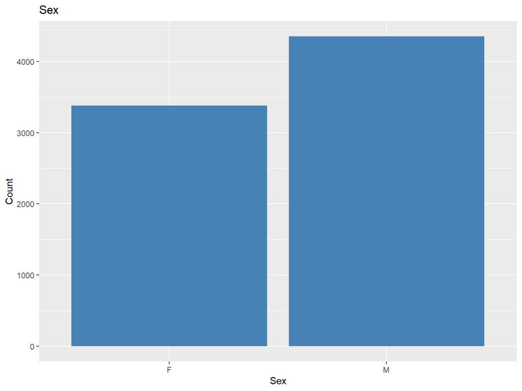

```r
#Distrubution of Patients by Sex
sex_plot <- ggplot(initial_admissions, aes(x = SEX)) +
  geom_bar(fill = "steelblue") +
  labs(
    title = "Sex",
    x = "Sex",
    y = "Count"
  )
sex_plot
```

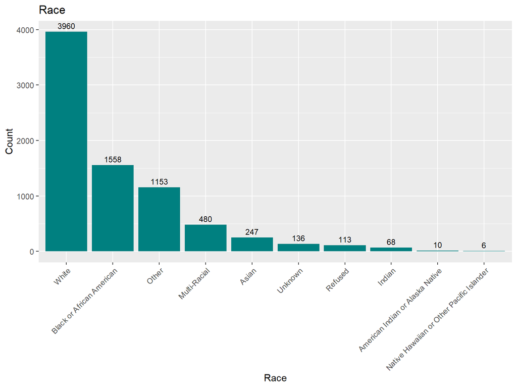

```r
# Distribution of Patients by Race
race_plot <- ggplot(initial_admissions, aes(x = fct_infreq(RACE))) +
  geom_bar(fill = "#008080") +
  geom_text(
    stat = "count",               # Use counts as the statistic
    aes(label = after_stat(count)),       # Display the count on top of bars
    vjust = -0.5,                 # Position the text slightly above the bars
    size = 3                      # Adjust text size
  ) +
  labs(
    title = "Race",
    x = "Race",
    y = "Count"
  ) +
  theme(
    axis.text.x = element_text(angle = 45, hjust = 1)  # Rotate x-axis labels
  )
race_plot
```

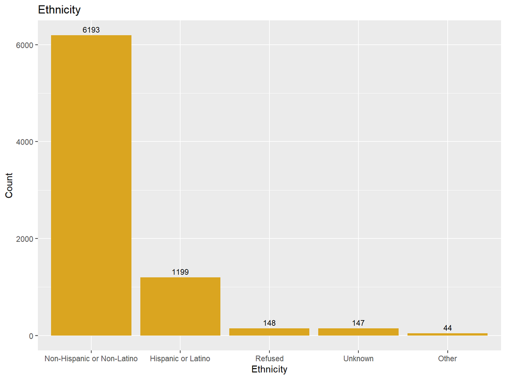

```r
# Distribution of Patients by Ethnicity
ethnicity_plot <- ggplot(initial_admissions, aes(x = fct_infreq(ETHNICITY))) +
  geom_bar(fill = "#DAA520") +
  geom_text(
    stat = "count",
    aes(label = after_stat(count)),
    vjust = -0.5,
    size = 3
  ) +
  labs(
    title = "Ethnicity",
    x = "Ethnicity",
    y = "Count"
  )
ethnicity_plot
```

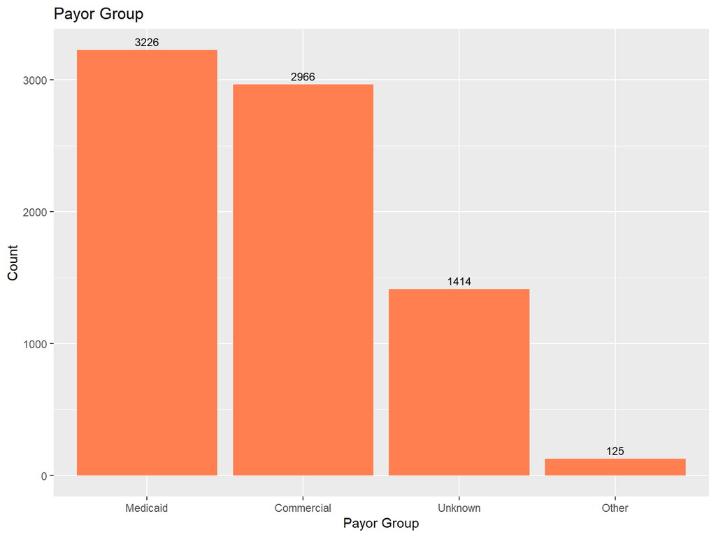

```r
# Distribution of Patients by Payor Group
payor_plot <- ggplot(initial_admissions, aes(x = fct_infreq(PAYOR_GROUP))) +
  geom_bar(fill = "#FF7F50") +
  geom_text(
    stat = "count",
    aes(label = after_stat(count)),
    vjust = -0.5,
    size = 3
  ) +
  labs(
    title = "Payor Group",
    x = "Payor Group",
    y = "Count"
  )
payor_plot
```

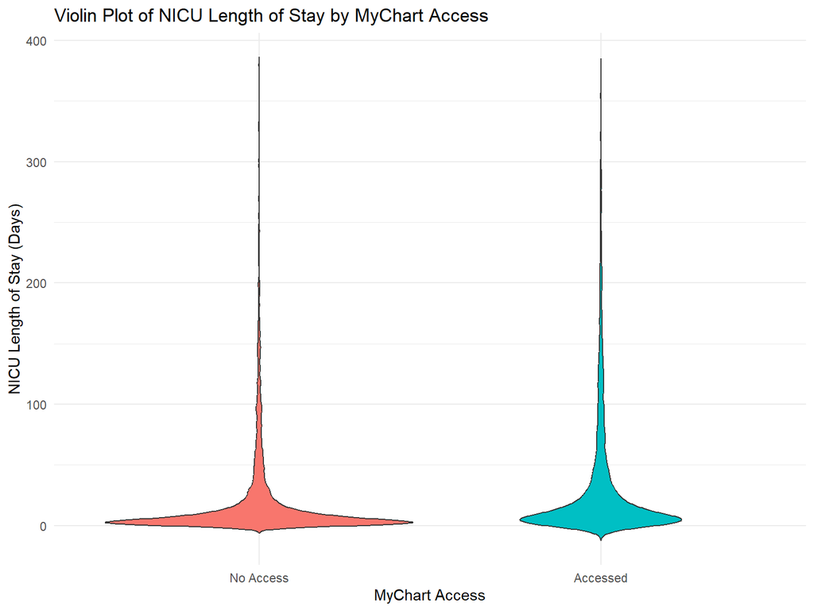

```r
# Create violin plots for each continuous variable
# NICU_LOS_Days
ggplot(initial_admissions, aes(x = MyChart_Access, y = NICU_LOS_DAYS, fill = MyChart_Access)) +
  geom_violin(trim = FALSE) +
  labs(title = "Violin Plot of NICU Length of Stay by MyChart Access",
       x = "MyChart Access",
       y = "NICU Length of Stay (Days)") +
  theme_minimal() +
  theme(legend.position = "none")
```

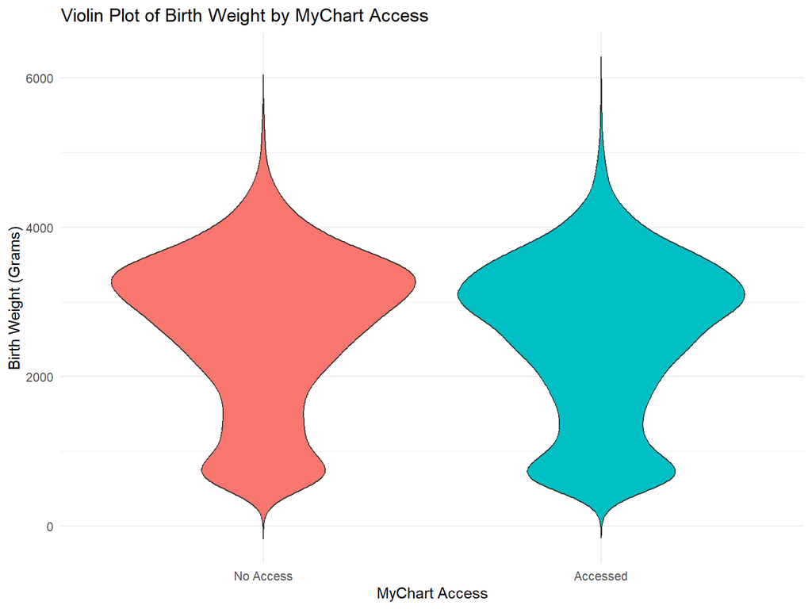

```r
# BIRTH_WEIGHT_GRAMS
ggplot(initial_admissions, aes(x = MyChart_Access, y = BIRTH_WEIGHT_GRAMS, fill = MyChart_Access)) +
  geom_violin(trim = FALSE) +
  labs(title = "Violin Plot of Birth Weight by MyChart Access",
       x = "MyChart Access",
       y = "Birth Weight (Grams)") +
  theme_minimal() +
  theme(legend.position = "none")
```

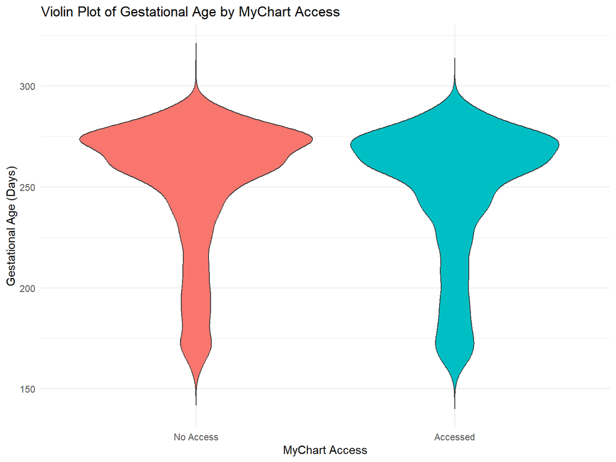

```r
# GESTATIONAL_AGE_TOTAL_DAYS
ggplot(initial_admissions, aes(x = MyChart_Access, y = GESTATIONAL_AGE_TOTAL_DAYS, fill = MyChart_Access)) +
  geom_violin(trim = FALSE) +
  labs(title = "Violin Plot of Gestational Age by MyChart Access",
       x = "MyChart Access",
       y = "Gestational Age (Days)") +
  theme_minimal() +
  theme(legend.position = "none")
```

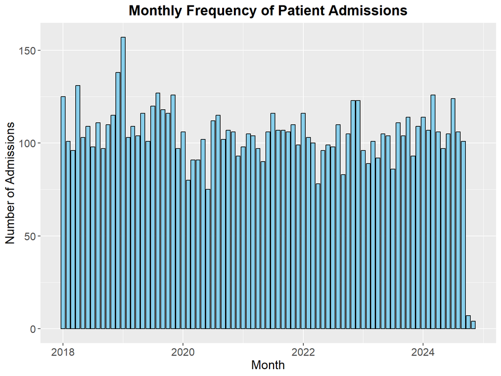

```r
# Graph showing overall admissions to the NICU (includes re-admitted patients to NICU)
# Aggregate data by month
monthly_data_all <- patient_data |>
  mutate(month = as.Date(cut(EPISODE_START_DATE, breaks = "month"))) |>
  group_by(month) |>
  summarise(frequency = n())

# Creating a timeline
ggplot(monthly_data_all, aes(x = month, y = frequency)) +
  geom_col(fill = "skyblue", color = "black") +
  labs(
    title = "Monthly Frequency of Patient Admissions",
    x = "Month",
    y = "Number of Admissions"
  ) +
  theme(
    plot.title = element_text(hjust = 0.5, size = 16, face = "bold"),
    axis.title = element_text(size = 14),
    axis.text = element_text(size = 12)
  )
```

## MyChart Access Data Display

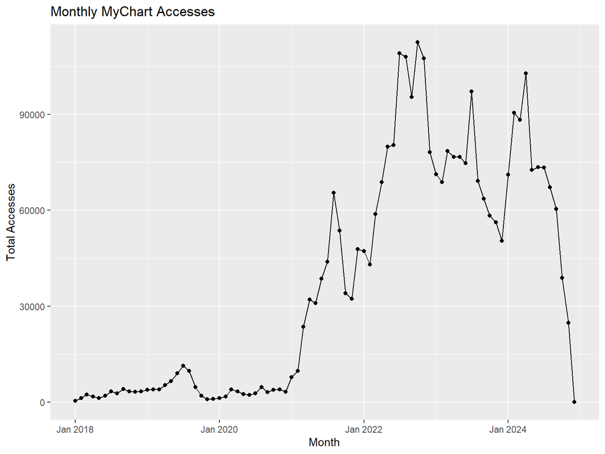

```r
# Aggregate monthly totals directly from access_data
monthly_access_data <- access_data |>
  mutate(month = as.Date(cut(UA_TIME, breaks = "month"))) |>
  group_by(month) |>
  summarise(
    total_accesses = n()  # Total MyChart accesses per month
  )

# Create a line plot for total MyChart accesses by month
ggplot(monthly_access_data, aes(x = month, y = total_accesses)) +
  geom_line() +
  geom_point() +
  labs(
    title = "Monthly MyChart Accesses",
    x = "Month",
    y = "Total Accesses"
  ) +
  scale_x_date(date_labels = "%b %Y")   # Format x-axis labels as "Month Year"
```

```r
#Exploration of MyChart access. First we will filter by MRN to assess how many times MyChart is accessed per MRN
access_summary_per_patient <- access_data |>
  group_by(MRN) |>
  summarise(access_count = n())

access_summary_per_patient <- access_summary_per_patient |>
  arrange(desc(access_count))

head(access_summary_per_patient$access_count, n = 10) #showing some of the most active users having 56k, 45k, 35k, 33k etc
```

```
 [1] 56844 45388 41080 35476 33376 31933 25015 24603 23728 22603
```

```r
summary(access_summary_per_patient$access_count)
```

```
   Min. 1st Qu.  Median    Mean 3rd Qu.    Max.
    1.0    14.0    77.0   694.9   333.0 56844.0
```

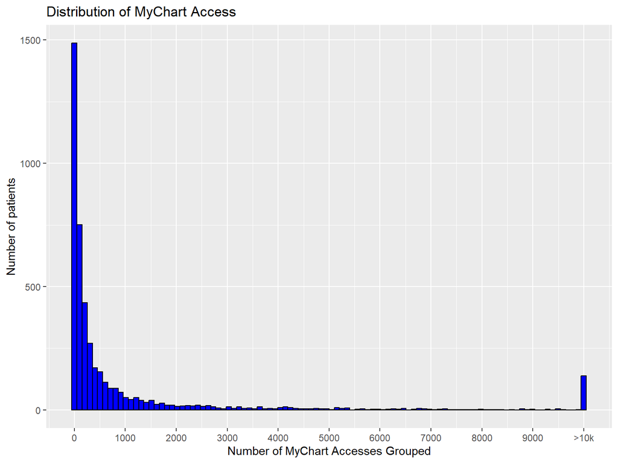

```r
access_summary_per_patient_graph <- access_summary_per_patient %>%
  mutate(
    capped_access_count = ifelse(access_count > 5000, 5000, access_count)
  )

# Plot the data with grouped values
ggplot(access_summary_per_patient_graph, aes(x = capped_access_count)) +
  geom_histogram(bins = 100, fill = "blue", color = "black") +
  scale_x_continuous(
    breaks = seq(0, 5000, by = 500),
    labels = c(seq(0, 9000, by = 1000), ">10k")
  ) +
  labs(
    title = "Distribution of MyChart Access",
    x = "Number of MyChart Accesses Grouped",
    y = "Number of patients"
  )
```

```r
# Exploration of what people are accessing most frequently accessing
# Count the frequency of codes in access_data
code_frequencies <- access_data %>%
  group_by(MYC_UA_TYPE_C) %>%
  summarise(Count = n()) %>%
  arrange(desc(Count))  # Sort by descending order of frequency

# Join with the epic_lookup_table to get descriptions
code_with_description <- code_frequencies %>%
  left_join(epic_lookup_table, by = c("MYC_UA_TYPE_C" = "Code"))

# View the result (top 50 most frequent actions)
top_actions <- code_with_description |>
  select(MYC_UA_TYPE_C, Description, Count) |>
  head(50)
top_actions
```

```
# A tibble: 50 × 3
   MYC_UA_TYPE_C Description           Count
           <int> <chr>                 <int>
 1            12 Visits               578019
 2            66 Inpatient Admissions 269426
 3           102 Proxy Context Enter  244982
 4             4 Test Result Details  235654
 5           272 Health Feed          213007
 6            41 Test Results List    201726
 7         96080 View Treatment Team  173287
 8           279 Explore More         163012
 9         96140 Load Consent List    138405
10           103 Proxy Context Exit   136980
# ℹ 40 more rows
```

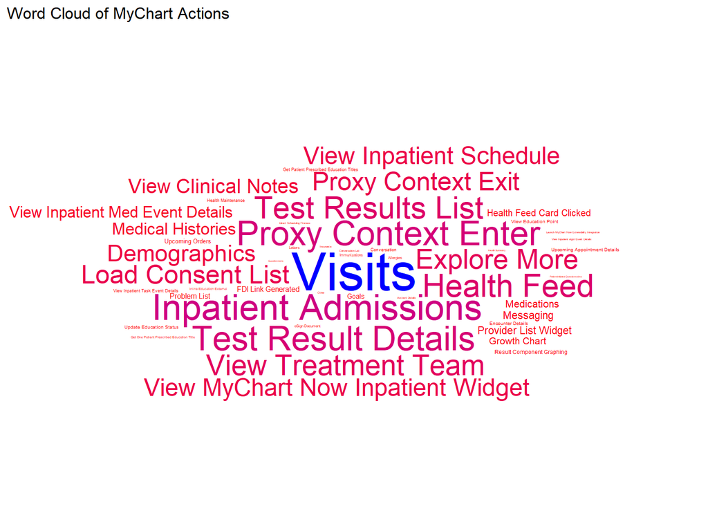

```r
# Creation of word cloud
ggplot(top_actions, aes(label = Description, size = Count, color = Count)) +
  geom_text_wordcloud() +
  scale_size_area(max_size = 15) +  # Adjust the maximum size of the words
  scale_color_gradient(low = "red", high = "blue") +
  theme_minimal() +
  labs(
    title = "Word Cloud of MyChart Actions"
  )
```

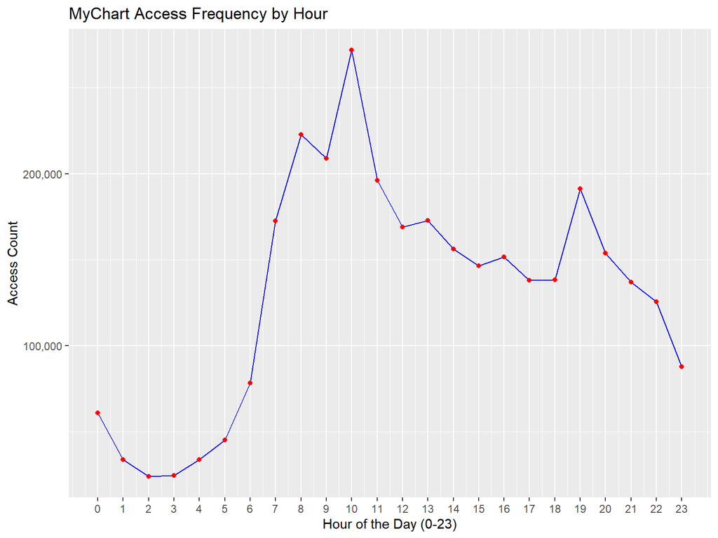

```r
# Exploration of time of day most often accessed
# Group access by hour
access_by_hour <- access_data |>
  mutate(hour = hour(UA_TIME)) |>  # Extract the hour from UA_TIME
  group_by(hour) |>
  summarize(access_count = n(), .groups = "drop")

ggplot(access_by_hour, aes(x = hour, y = access_count)) +
  geom_line(color = "blue") +
  geom_point(color = "red") +
  labs(
    title = "MyChart Access Frequency by Hour",
    x = "Hour of the Day (0-23)",
    y = "Access Count"
  ) +
  scale_x_continuous(breaks = 0:23) +  # Ensure all hours are displayed
  scale_y_continuous(labels = comma)
```

## Predictive Modeling

Below are a few predictive models that I created based on the datasets I created. I recognize the fair amount of missing variables found within certain characterisitcs such as Race, Ethnicity, Language, etc. I am hopeful to improve my datasets through future iterative data exploration within CHOP’s data warehouse.

```r
## Create the primary table that I will use for various models
primary_model <- initial_admissions %>%
  select(
    SEX,
    RACE,
    ETHNICITY,
    PREFERRED_LANGUAGE,
    PAYOR_GROUP,
    BIRTH_WEIGHT_GRAMS,
    EPISODE_START_DATE,
    NICU_LOS_DAYS,
    INBORN_IND,
    GESTATIONAL_AGE_TOTAL_DAYS,
    MyChart_Access
  )

# Converting date to time periods and factor we can use
primary_model$date_period <- dplyr::case_when(
  primary_model$EPISODE_START_DATE < as.Date("2020-01-01") ~ "01-2018 to 12-2019",
  primary_model$EPISODE_START_DATE >= as.Date("2020-01-01") & primary_model$EPISODE_START_DATE < as.Date("2022-01-01") ~ "01-2020 to 12-2021",
  primary_model$EPISODE_START_DATE >= as.Date("2022-01-01") ~ "01-2022 to 09-2024"
)

# Convert outcome variables to factor
primary_model$INBORN_IND <- as.factor(primary_model$INBORN_IND)
primary_model$date_period <- as.factor(primary_model$date_period)
```

```r
## Logistic regression model
# Set the engine for logistic regression
logistic_model <-
  logistic_reg() |>
  set_engine("glm")

# Fit the model
logistic_fit <-
  logistic_model |>
  fit(MyChart_Access ~ SEX + RACE + ETHNICITY + PREFERRED_LANGUAGE + PAYOR_GROUP +
    BIRTH_WEIGHT_GRAMS + NICU_LOS_DAYS + INBORN_IND + GESTATIONAL_AGE_TOTAL_DAYS + date_period
    , data = primary_model)

# Visualize information
tidy(logistic_fit)
```

```
# A tibble: 34 × 5
   term                                 estimate std.error statistic     p.value
   <chr>                                   <dbl>     <dbl>     <dbl>       <dbl>
 1 (Intercept)                           -1.97      0.362     -5.43      5.55e-8
 2 SEXM                                   0.0257    0.0570     0.451     6.52e-1
 3 RACEBlack or African American         -0.409     0.0805    -5.08      3.70e-7
 4 RACEOther                             -0.345     0.0980    -3.52      4.25e-4
 5 RACEMulti-Racial                      -0.142     0.121     -1.18      2.38e-1
 6 RACEAsian                             -0.0324    0.171     -0.190     8.49e-1
 7 RACEUnknown                           -0.979     0.315     -3.11      1.88e-3
 8 RACERefused                           -0.311     0.299     -1.04      2.98e-1
 9 RACEIndian                             0.235     0.305      0.772     4.40e-1
10 RACEAmerican Indian or Alaska Native   0.121     0.803      0.150     8.80e-1
# ℹ 24 more rows
```

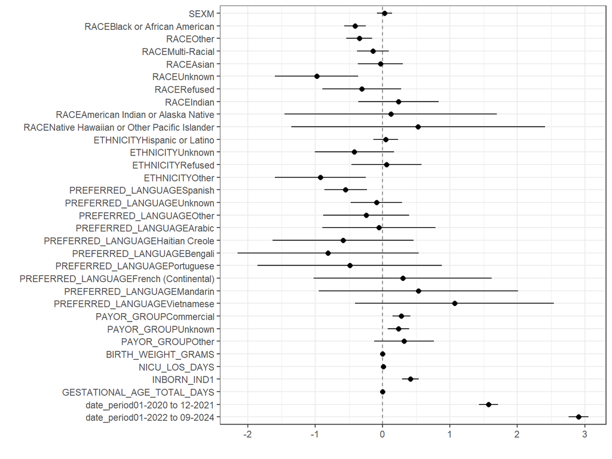

```r
# Creation of whisker plot fit coefficients
tidy(logistic_fit) |>
  dwplot(dot_args = list(size = 2, color = "black"),
         whisker_args = list(color = "black"),
         vline = geom_vline(xintercept = 0, colour = "grey50", linetype = 2)) +
  theme_bw()
```

```r
#
logistic_training_pred <- bind_cols(
  truth = primary_model$MyChart_Access,
  predict(logistic_fit, primary_model, type = "class"),
  predict(logistic_fit, primary_model, type = "prob")
)

logistic_training_pred
```

```
# A tibble: 7,731 × 4
   truth     .pred_class `.pred_No Access` .pred_Accessed
   <fct>     <fct>                   <dbl>          <dbl>
 1 No Access No Access               0.866         0.134
 2 Accessed  No Access               0.863         0.137
 3 No Access <NA>                   NA            NA
 4 No Access No Access               0.903         0.0970
 5 Accessed  No Access               0.868         0.132
 6 No Access <NA>                   NA            NA
 7 No Access No Access               0.912         0.0877
 8 Accessed  No Access               0.851         0.149
 9 No Access No Access               0.862         0.138
10 No Access No Access               0.897         0.103
# ℹ 7,721 more rows
```

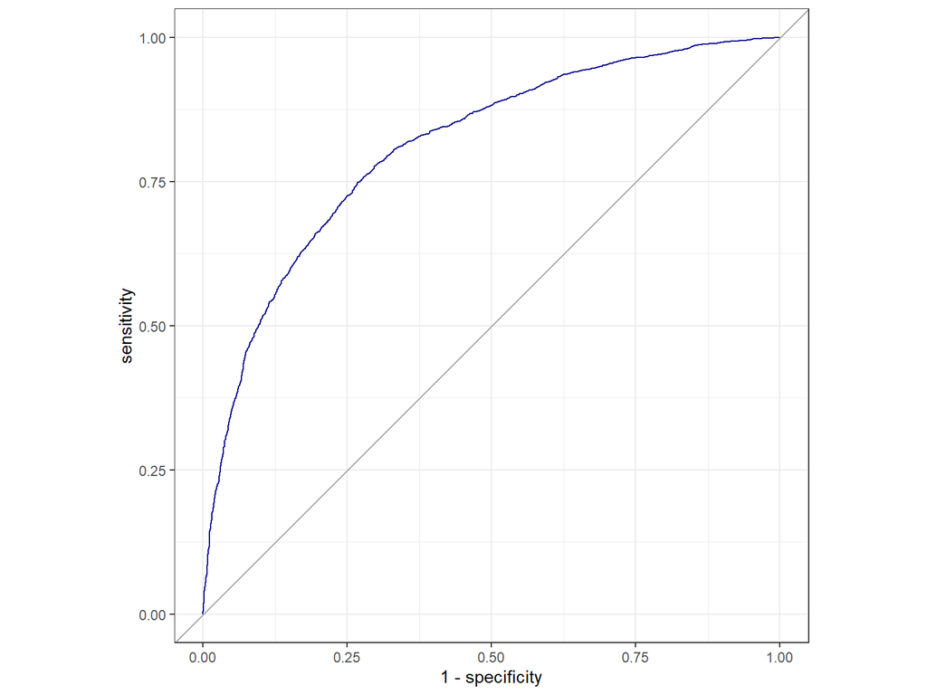

```r
# Plot of ROC curve
logistic_training_pred |>
  roc_curve(truth, ".pred_No Access") |>
  ggplot(aes(x = 1 - specificity, y = sensitivity)) +
  geom_path(color = "darkblue") +
  geom_abline(color = "darkgrey") +
  coord_equal() +
  theme_bw()
```

```r
# Area under the ROC curve
roc_auc(logistic_training_pred,
        truth,
        ".pred_No Access")
```

```
# A tibble: 1 × 3
  .metric .estimator .estimate
  <chr>   <chr>          <dbl>
1 roc_auc binary         0.810
```

```r
## 10-Fold Cross Validation and use of a Logistic Regression Model

set.seed(1234)
pmodel_folds <- vfold_cv(primary_model, v = 10)
pmodel_folds
```

```
#  10-fold cross-validation
# A tibble: 10 × 2
   splits             id
   <list>             <chr>
 1 <split [6957/774]> Fold01
 2 <split [6958/773]> Fold02
 3 <split [6958/773]> Fold03
 4 <split [6958/773]> Fold04
 5 <split [6958/773]> Fold05
 6 <split [6958/773]> Fold06
 7 <split [6958/773]> Fold07
 8 <split [6958/773]> Fold08
 9 <split [6958/773]> Fold09
10 <split [6958/773]> Fold10
```

```r
# Create a workflow() for fitting the glm
glm_wf <- workflow() |>
  add_model(logistic_model) |>
  add_formula(MyChart_Access ~ SEX + RACE + ETHNICITY + PREFERRED_LANGUAGE + PAYOR_GROUP +
    BIRTH_WEIGHT_GRAMS + NICU_LOS_DAYS + INBORN_IND + GESTATIONAL_AGE_TOTAL_DAYS + date_period)

# Use workflow to fit model with each fold of resampled data
glm_fit_cv <- glm_wf |>
  fit_resamples(pmodel_folds, control = control_resamples(save_pred = TRUE))

# Collect predictions out of folds into one tibble
pmodels_glm_cv_preds <- collect_predictions(glm_fit_cv)
pmodels_glm_cv_preds
```

```
# A tibble: 7,731 × 7
   .pred_class `.pred_No Access` .pred_Accessed id      .row MyChart_Access
   <fct>                   <dbl>          <dbl> <chr>  <int> <fct>
 1 No Access               0.727         0.273  Fold01    43 No Access
 2 No Access               0.746         0.254  Fold01    61 Accessed
 3 No Access               0.829         0.171  Fold01    63 No Access
 4 No Access               0.830         0.170  Fold01    68 No Access
 5 No Access               0.866         0.134  Fold01    72 No Access
 6 No Access               0.831         0.169  Fold01    74 No Access
 7 No Access               0.846         0.154  Fold01    81 Accessed
 8 No Access               0.904         0.0964 Fold01    89 No Access
 9 No Access               0.809         0.191  Fold01    92 No Access
10 No Access               0.811         0.189  Fold01    97 No Access
# ℹ 7,721 more rows
# ℹ 1 more variable: .config <chr>
```

```r
# Overall metrics
collect_metrics(glm_fit_cv)
```

```
# A tibble: 3 × 6
  .metric     .estimator  mean     n std_err .config
  <chr>       <chr>      <dbl> <int>   <dbl> <chr>
1 accuracy    binary     0.730    10 0.00699 Preprocessor1_Model1
2 brier_class binary     0.179    10 0.00316 Preprocessor1_Model1
3 roc_auc     binary     0.806    10 0.00658 Preprocessor1_Model1
```

```r
# To see performance of each fold
pmodels_glm_cv_preds |>
  group_by(id) |>
  roc_auc(MyChart_Access, ".pred_No Access")
```

```
# A tibble: 10 × 4
   id     .metric .estimator .estimate
   <chr>  <chr>   <chr>          <dbl>
 1 Fold01 roc_auc binary         0.792
 2 Fold02 roc_auc binary         0.828
 3 Fold03 roc_auc binary         0.820
 4 Fold04 roc_auc binary         0.787
 5 Fold05 roc_auc binary         0.789
 6 Fold06 roc_auc binary         0.812
 7 Fold07 roc_auc binary         0.839
 8 Fold08 roc_auc binary         0.817
 9 Fold09 roc_auc binary         0.772
10 Fold10 roc_auc binary         0.809
```

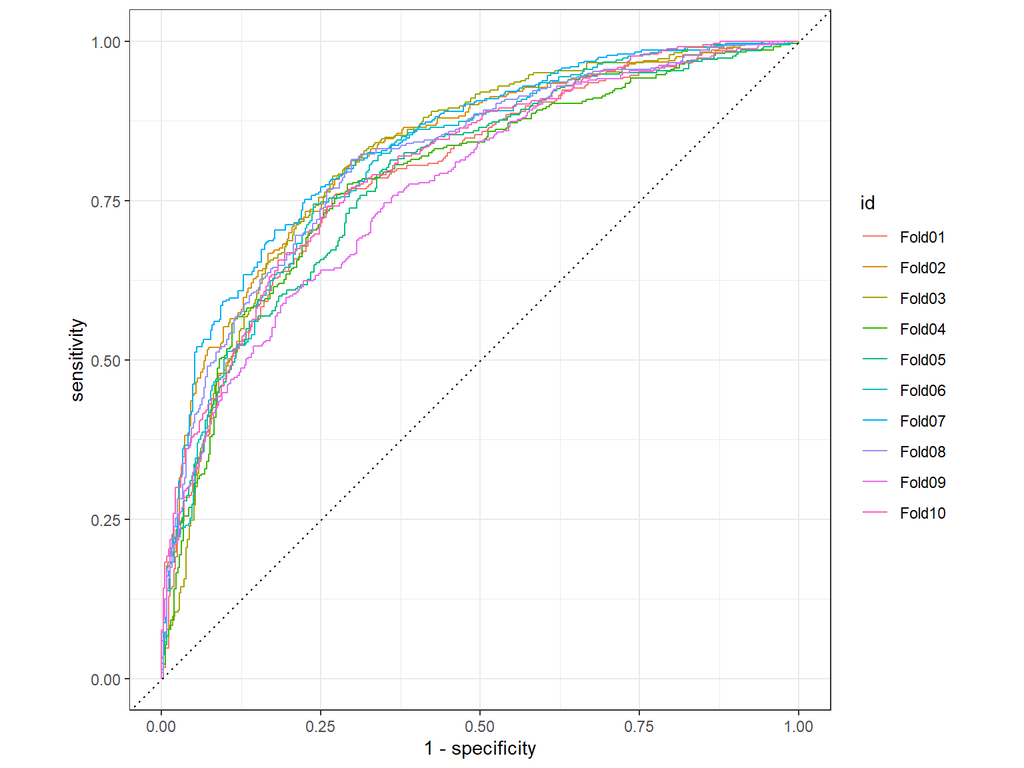

```r
# ROC curves of each fold
pmodels_glm_cv_preds |>
  group_by(id) |>
  roc_curve(MyChart_Access, ".pred_No Access") |>
  autoplot()
```

```r
## Random Forest Modeling

# Check for missing data
summary(primary_model)
```

```
 SEX                             RACE                           ETHNICITY
 F:3379   White                    :3960   Non-Hispanic or Non-Latino:6193
 M:4352   Black or African American:1558   Hispanic or Latino        :1199
          Other                    :1153   Unknown                   : 147
          Multi-Racial             : 480   Refused                   : 148
          Asian                    : 247   Other                     :  44
          Unknown                  : 136
          (Other)                  : 197
      PREFERRED_LANGUAGE     PAYOR_GROUP   BIRTH_WEIGHT_GRAMS
 English       :7057     Medicaid  :3226   Min.   : 365
 Spanish       : 323     Commercial:2966   1st Qu.:1900
 Unknown       : 182     Unknown   :1414   Median :2822
 Other         :  58     Other     : 125   Mean   :2592
 Arabic        :  31                       3rd Qu.:3360
 Haitian Creole:  19                       Max.   :5735
 (Other)       :  61                       NA's   :507
 EPISODE_START_DATE               NICU_LOS_DAYS      INBORN_IND
 Min.   :2018-01-01 00:56:00.00   Min.   :  0.1708   0:5625
 1st Qu.:2019-07-22 02:30:00.00   1st Qu.:  3.2417   1:2106
 Median :2021-04-03 16:57:00.00   Median :  8.8604
 Mean   :2021-04-20 02:47:53.28   Mean   : 28.4748
 3rd Qu.:2023-01-01 02:04:00.00   3rd Qu.: 27.7521
 Max.   :2024-10-03 14:34:00.00   Max.   :379.9688

 GESTATIONAL_AGE_TOTAL_DAYS   MyChart_Access             date_period
 Min.   :155.0              No Access:3768   01-2018 to 12-2019:2487
 1st Qu.:238.0              Accessed :3963   01-2020 to 12-2021:2211
 Median :261.0                               01-2022 to 09-2024:3033
 Mean   :249.7
 3rd Qu.:273.0
 Max.   :308.0
 NA's   :125
```

```r
# Impute missing numerical values with the median
primary_model <- primary_model |>
  mutate(
    BIRTH_WEIGHT_GRAMS = ifelse(is.na(BIRTH_WEIGHT_GRAMS), median(BIRTH_WEIGHT_GRAMS, na.rm = TRUE), BIRTH_WEIGHT_GRAMS),
    GESTATIONAL_AGE_TOTAL_DAYS = ifelse(is.na(GESTATIONAL_AGE_TOTAL_DAYS), median(GESTATIONAL_AGE_TOTAL_DAYS, na.rm = TRUE), GESTATIONAL_AGE_TOTAL_DAYS)
  )

# Create a random index for the training set
set.seed(123)
train_index <- sample(seq_len(nrow(primary_model)), size = 0.8 * nrow(primary_model))

# Split the primary_model into training and testing sets
train_data <- primary_model[train_index, ]  # 80% of the data
test_data <- primary_model[-train_index, ]  # Remaining 20%

# Random Forest Model specification
rf_spec <-
  rand_forest(trees = 1000, min_n = 5) |> #number of trees and min # of data points
  set_engine("randomForest", importance = TRUE) |>
  set_mode("classification")

# Fit our data to the random forest model
rf_fit <- rf_spec |>
  fit(MyChart_Access ~ SEX + RACE + ETHNICITY + PREFERRED_LANGUAGE + PAYOR_GROUP +
    BIRTH_WEIGHT_GRAMS + NICU_LOS_DAYS + INBORN_IND + GESTATIONAL_AGE_TOTAL_DAYS + date_period, data = train_data)
rf_fit
```

```
parsnip model object


Call:
 randomForest(x = maybe_data_frame(x), y = y, ntree = ~1000, nodesize = min_rows(~5,      x), importance = ~TRUE)
               Type of random forest: classification
                     Number of trees: 1000
No. of variables tried at each split: 3

        OOB estimate of  error rate: 26.33%
Confusion matrix:
          No Access Accessed class.error
No Access      2123      869   0.2904412
Accessed        759     2433   0.2377820
```

```r
pmodel.rf.pred.values <- bind_cols(
  truth = test_data$MyChart_Access,
  predict(rf_fit, test_data),
  predict(rf_fit, test_data, type = "prob")
)
pmodel.rf.pred.values
```

```
# A tibble: 1,547 × 4
   truth     .pred_class `.pred_No Access` .pred_Accessed
   <fct>     <fct>                   <dbl>          <dbl>
 1 No Access No Access               0.948          0.052
 2 Accessed  No Access               0.897          0.103
 3 No Access No Access               0.873          0.127
 4 Accessed  No Access               0.681          0.319
 5 No Access No Access               0.598          0.402
 6 No Access No Access               0.76           0.24
 7 No Access No Access               0.846          0.154
 8 No Access No Access               0.982          0.018
 9 No Access No Access               0.927          0.073
10 No Access No Access               0.875          0.125
# ℹ 1,537 more rows
```

```r
roc_auc(pmodel.rf.pred.values,
        truth,
        ".pred_No Access")
```

```
# A tibble: 1 × 3
  .metric .estimator .estimate
  <chr>   <chr>          <dbl>
1 roc_auc binary         0.804
```

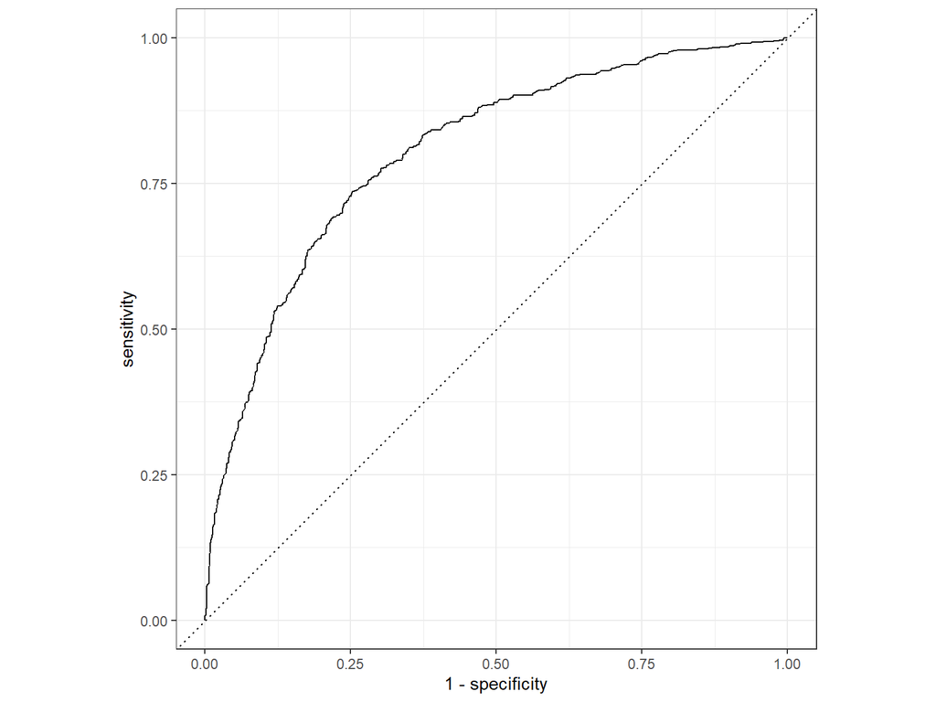

```r
# Creation of the ROC curve
autoplot(roc_curve(pmodel.rf.pred.values,
                   truth,
                   ".pred_No Access"))
```

```r
# Helps to understand the variables that contributed the most to the classification
rf_fit |>
  extract_fit_engine() |>
  importance()
```

```
                            No Access    Accessed MeanDecreaseAccuracy
SEX                          2.949055   3.6633555             4.666386
RACE                         6.692545  11.7348007            14.492239
ETHNICITY                   -2.313909  10.2746271             6.671433
PREFERRED_LANGUAGE           8.276474   0.5970703             6.203801
PAYOR_GROUP                 17.043278   8.1757692            19.336878
BIRTH_WEIGHT_GRAMS          17.597852  28.4071676            39.580255
NICU_LOS_DAYS               55.969556  54.6072349            78.411856
INBORN_IND                   2.405897  32.8972908            28.473057
GESTATIONAL_AGE_TOTAL_DAYS   9.671064  37.7458904            43.822405
date_period                251.224753 248.1814803           310.754249
                           MeanDecreaseGini
SEX                                47.27940
RACE                              135.34361
ETHNICITY                          60.29923
PREFERRED_LANGUAGE                 49.34187
PAYOR_GROUP                        87.16375
BIRTH_WEIGHT_GRAMS                366.00116
NICU_LOS_DAYS                     509.34895
INBORN_IND                         39.46497
GESTATIONAL_AGE_TOTAL_DAYS        306.30529
date_period                       759.00876
```

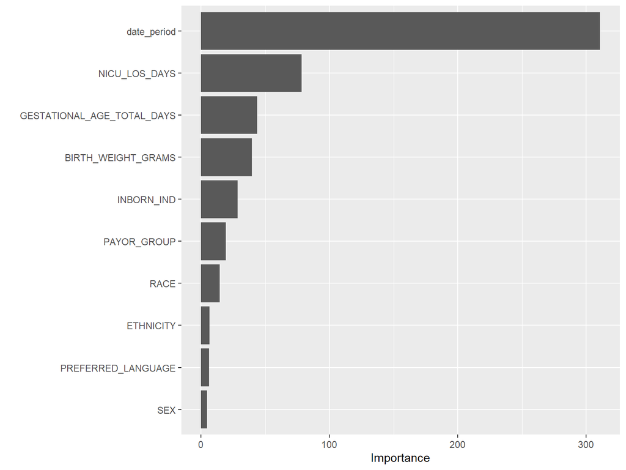

```r
rf_fit |>
  extract_fit_engine() |>
  vip()
```

```r
## XGBoost Modeling

# Model specification
bt_spec <-
  boost_tree(trees = 50,
             tree_depth = 4) |>
  set_mode("classification") |>
  set_engine("xgboost")

bt_recipe <-
  recipe(MyChart_Access ~ SEX + RACE + ETHNICITY + PREFERRED_LANGUAGE + PAYOR_GROUP +
    BIRTH_WEIGHT_GRAMS + NICU_LOS_DAYS + INBORN_IND + GESTATIONAL_AGE_TOTAL_DAYS + date_period, data = primary_model) |>
  step_dummy(all_nominal_predictors()) |>
  step_normalize(all_predictors())

# Workflow specification
bt_workflow <- workflow() |>
  add_model(bt_spec) |>
  add_recipe(bt_recipe)

# Model fit to training data
bt_fit <- fit(bt_workflow, data = primary_model)
bt_fit
```

```
══ Workflow [trained] ══════════════════════════════════════════════════════════
Preprocessor: Recipe
Model: boost_tree()

── Preprocessor ────────────────────────────────────────────────────────────────
2 Recipe Steps

• step_dummy()
• step_normalize()

── Model ───────────────────────────────────────────────────────────────────────
##### xgb.Booster
raw: 80.4 Kb
call:
  xgboost::xgb.train(params = list(eta = 0.3, max_depth = 4, gamma = 0,
    colsample_bytree = 1, colsample_bynode = 1, min_child_weight = 1,
    subsample = 1), data = x$data, nrounds = 50, watchlist = x$watchlist,
    verbose = 0, nthread = 1, objective = "binary:logistic")
params (as set within xgb.train):
  eta = "0.3", max_depth = "4", gamma = "0", colsample_bytree = "1", colsample_bynode = "1", min_child_weight = "1", subsample = "1", nthread = "1", objective = "binary:logistic", validate_parameters = "TRUE"
xgb.attributes:
  niter
callbacks:
  cb.evaluation.log()
# of features: 33
niter: 50
nfeatures : 33
evaluation_log:
  iter training_logloss
 <num>            <num>
     1        0.6153372
     2        0.5737878
   ---              ---
    49        0.4611228
    50        0.4598103
```

```r
pmodel.bt.pred.values <- bind_cols(
  truth = primary_model$MyChart_Access,
  predict(bt_fit, primary_model),
  predict(bt_fit, primary_model, type = "prob")
)

# Model AUC suprisingly highly successful
roc_auc(pmodel.bt.pred.values,
        truth,
        ".pred_No Access")
```

```
# A tibble: 1 × 3
  .metric .estimator .estimate
  <chr>   <chr>          <dbl>
1 roc_auc binary         0.868
```

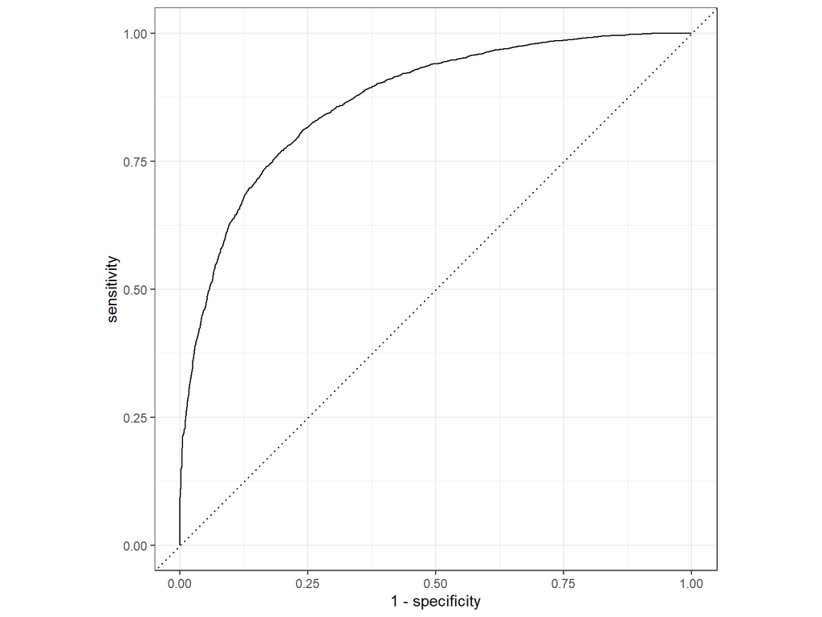

```r
# Plot ROC curve
autoplot(roc_curve(pmodel.bt.pred.values,
                   truth,
                   ".pred_No Access"))
```

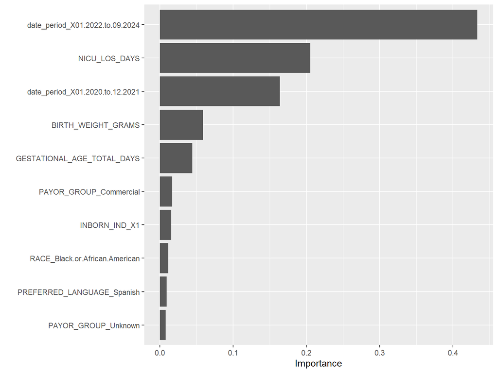

```r
# Variable importance extracted with vip
vip(bt_fit)
```

# Conclusion

The predictive modeling aspect of this project was primarily an interest of mine to better understand the data. I was pleasantly surprised by the results of the ROC curves, as I had not anticipated achieving such respectable outcomes. With ROC AUCs predominantly ranging from 0.8 to 0.9, the models demonstrated good discrimination overall, with the XGBoost model emerging as the most successful. While I do not believe these models have current practical implications, they provide valuable insights into the characteristics and key factors influencing patients most likely to access MyChart.

## Limitations

Our team acknowledges the presence of a significant amount of missing information, particularly in key demographic categories such as race, ethnicity, language, and payor group. To address these gaps, we are planning several initiatives, including leveraging birth certificate data, examining interpreter utilization records at CHOP, and exploring payor group information within billing records. The predictive modeling aspect of this project primarily reflects my personal interest in practicing and exploring prediction modeling techniques. I also recognize the need to fine-tune the models to address the skewed nature of MyChart access data by date, which likely contributes substantially to the models’ success.

# References

1. Children’s Hospital of Philadelphia. MyChart FAQ. Retrieved December 5, 2024, from https://mychop.chop.edu/MyChart/Authentication/Login?mode=stdfile&option=faq#EQ_what
2. Bush RA, Vemulakonda VM, Richardson AC, Deakyne Davies SJ, Chiang GJ. Providing Access: Differences in Pediatric Portal Activation Begin at Patient Check-in. Appl Clin Inform. 2019 Aug;10(4):670-678. doi: 10.1055/s-0039-1695792. Epub 2019 Sep 11. PMID: 31509879; PMCID: PMC6739202.
3. Office of the Assistant Secretary for Planning and Evaluation. (August 20, 1996). Health Insurance Portability and Accountability Act of 1996. U.S. Department of Health and Human Services. https://aspe.hhs.gov/reports/health-insurance-portability-accountability-act-1996
4. U.S. Food and Drug Administration. (n.d.). 21st Century Cures Act. U.S. Department of Health and Human Services. https://www.fda.gov/regulatory-information/selected-amendments-fdc-act/21st-century-cures-act
5. Harvard Risk Management Foundation. (2021, December 9). Cures Act overview. Harvard Risk Management Foundation. https://www.rmf.harvard.edu/Risk-Prevention-and-Education/Article-Catalog-Page/Articles/2021/Cures-Act-Overview